# MMID Practical: IBM

Ricardo Águas

MSc MGH course, 2022

Let’s code an individual based model in R!

Type in the lines of code in the boxes sequentially into your R Studio script editor.

#### Setting up initial conditions and parameters

Let’s start by creating a new R script. For simplicity, we’ll model only 20 individuals, starting with 19 susceptible people and 1 infected. We want to see how transmission is happening for 10 timesteps. This is how to set that up in R:

```r
initS <- 19
initI <- 1
no.of.timesteps <- 10
```

#### Build your model framework

Revisit the compartmental models described before and write down the diagram for an SEIR model:

Let’s consider a coding system to represent the possible state variables. For simplicity, let’s use the following:

Susceptible – 0

Exposed – 1

Infectious – 2

To initialize your population of 20 individuals, run the following code to store our simple population in a vector called ‘pop’.

```r
pop <- c(rep(0,initS), rep(2,initI))
pop
```

```
##  [1] 0 0 0 0 0 0 0 0 0 0 0 0 0 0 0 0 0 0 0 2
```

Now that you’ve created your population, you can simulate the system’s dynamics over 10 timesteps. But, wait! To help with visualization of the system behavior over time we need a place to store the sum of the individual state variables at each timestep.

#### Creating a table to store the results of simulation

Let’s create a data frame called ‘sim.table’ that stores the sum of each state variable at each timestep:

```r
sim.table <- as.data.frame(matrix(NA, no.of.timesteps,5))
```

This is a table of 5 columns with ‘no.of.timesteps’ as the number of rows. Let’s change the column names to our state variable names:

```r
colnames(sim.table) <- c('WeekNo', 'S', 'E', 'I', 'R')
sim.table
```

```
##    WeekNo  S  E  I  R
## 1      NA NA NA NA NA
## 2      NA NA NA NA NA
## 3      NA NA NA NA NA
## 4      NA NA NA NA NA
## 5      NA NA NA NA NA
## 6      NA NA NA NA NA
## 7      NA NA NA NA NA
## 8      NA NA NA NA NA
## 9      NA NA NA NA NA
## 10     NA NA NA NA NA
```

#### Describe what can happen every timestep

We’ll try to describe all processes happening every timestep as they would in real life. Initially, our population has 20 (19 susceptible and 1 infectious) individuals. This is reflected in the initialization of pop.

To simulate the processes taking place in our system at each timestep we will use a ‘for’ loop:

```r
for(t in 1:no.of.timesteps)
{
  #Simulate what happens at each timestep
}
```

To efficiently store the updated summary of the state variables at each timestep:

```r
sim.table$WeekNo[t] <- t
sim.table$S[t]      <- sum(pop==0)
sim.table$E[t]      <- sum(pop==1)
sim.table$I[t]      <- sum(pop==2)
sim.table$R[t]      <- sum(pop==3)
```

#### Implementing transmission

For each individual, the probability of infection is a reflection of his/hers susceptibility and the number of infectious contacts he/she receives each timestep. Let’s say the number of potentially infectious contacts is given by parameter beta.

Create parameter beta and assign it a value between 2 and 5. If I have 1 contact per day, the chances that I will become infected is given by the probability that that 1 person I have contract with is presently infectious.

So, let’s create a variable lambda to represent the probability that a contact occurs with a presently infectious individual:

```r
beta <- 3
lambda <- beta.sum(pop==2)/length(pop)
```

Now let’s make it realistic by making it stochastic. In programming terms that means assigning some randomness to the contacts between individuals to assess whether or not an infection takes place. We start by casting a uniformly distributed random number for each individual.

```r
random.no <- runif(length(pop))
random.no
```

```
##  [1] 0.899206699 0.459806562 0.296568571 0.047759547 0.865493305 0.834644194
##  [7] 0.185654626 0.408658590 0.261624649 0.177434294 0.754183609 0.767822758
## [13] 0.608085787 0.004451596 0.856742630 0.256164034 0.050714532 0.338313943
## [19] 0.796567407 0.693272736
```

So, let’s implement the transmission process at the individual level. For this we need another ‘for’ loop.

#### Let’s look at individuals one by one

```r
for(i in 1:length(pop))
{
#Simulate what happens to each individual
}
```

Remember that these processes are all happening in a single timestep. So this second ‘for’ loop has to be within the first ‘for’ loop. Also note the difference in loop lengths. If we take lambda to literally be the probability to become infectious in each timestep, we simply have to test whether the random number created for each individual is less than lambda. Obviously, you need to check the susceptibility condition. If an individual is susceptible (ie. state 0), we’ll compare its corresponding random no. with lambda. If it’s less than lambda, the individual gets infected and we change that individual’s state to 1 (first week of infection).

```r
if(pop[i]==0)
{
      if(random.no[i]<lambda)
{
        pop[i]<- 1
      }
}
```

Let’s say each timestep is equivalent to one week and that both latent and infectious periods are also one week. If individuals are latent or infectious, we’ll just move them on to the next state each timestep. Since we’ve coded the states S, E, I and R numerically as 0, 1, 2, and 3 respective, we just have to add 1 to move them to the next state.

```r
else if(pop[i]==1 | pop[i]==2)
{
      pop[i] <- pop[i] + 1
}
```

That’s it. You’ve just written your first individual-based model in R! The full code:

```r
initS <- 19
initI <- 1
beta <- 1.5
gamma<-1
tau<-1
no.of.timesteps <- 10
pop <- c(rep(0,initS),rep(1,initI))
sim.table <- as.data.frame(matrix(NA, no.of.timesteps, 5))
colnames(sim.table) <- c('WeekNo','S','E','I','R')

for(t in 1:no.of.timesteps)
{
  #Simulate what happens at each timestep
  sim.table$WeekNo[t] <- t
  sim.table$S[t]  <- sum(pop==0)
  sim.table$E[t] <- sum(pop==1)
  sim.table$I[t] <- sum(pop==2)
  sim.table$R[t]  <- sum(pop==3)
  lambda <- beta*sum(pop==1| pop==2)/length(pop)
  random.no <- runif(length(pop))

  for(i in 1:length(pop))
  {
    #Simulate what happens to each individual
    if(pop[i]==0)
    {
      if(random.no[i]<lambda)
      {
        pop[i] <- 1
      }
    }
    else if(pop[i]==1 | pop[i]==2)
    {
      pop[i] <- pop[i] + 1
    }

  }

}
```

### Exercises

1. Create a graph from ‘sim.table’ similar to one below.

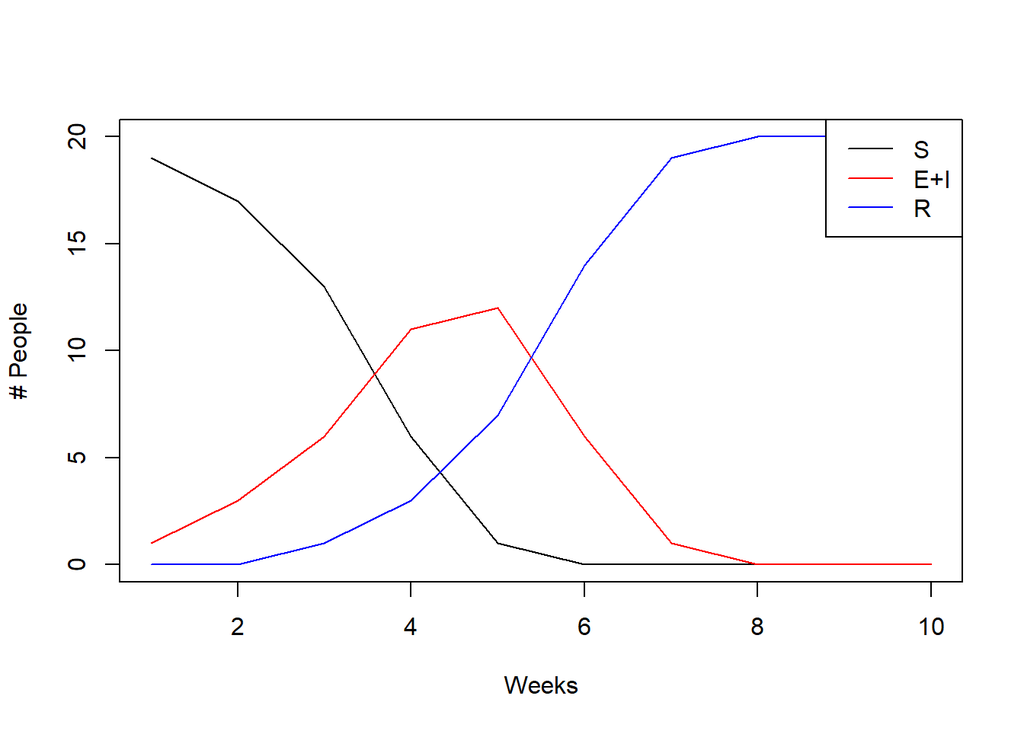

```r
plot(sim.table$WeekNo,sim.table$S,type='l',ylim=c(0,20),col='black',xlab="Weeks",ylab=("# People"))
lines(sim.table$WeekNo,sim.table$E+sim.table$I,col='red')
lines(sim.table$WeekNo,sim.table$R,col='blue')
legend("topright", legend = c("S","E+I","R"), lwd = 1, col=c("black","red","blue"))
```

2. Add a column to your ‘sim.table’ which shows the value of lambda each week.
3. Run the script a few times. Are the outputs always the same? How would you capture the variance observed in your runs?
4. Even for the simplest models, Individual-based simulations could be computationally expensive when you have a large population or when you run them for many timesteps. Experience it by changing parameters no.of.timesteps and initS.

## A more general framework including recovery and immunity loss

Let’s implement latency, recovery from infection and no immunity as stochastic processes to better reflect malaria epidemiology.

As before, let’s start by generating a vector pop of individuals and an output table sim.table.

```r
initS <- 19
initI <- 1
beta <- 0.5
no.of.timesteps <- 100
pop <- c(rep(0,initS),rep(1,initI))
sim.table <- as.data.frame(matrix(NA, no.of.timesteps, 5))
colnames(sim.table) <- c('Day','S','E','I','R')
```

Notice the change in number of timesteps. We are now using a daily timestep. Write the new function for the daily probability of infection lambda:

```r
for(t in 1:no.of.timesteps)
{
  #Simulate what happens at each timestep
  sim.table$Day[t] <- t
  sim.table$S[t] <- sum(pop==0)
  sim.table$E[t] <- sum(pop==1)
  sim.table$I[t] <- sum(pop==2)
  sim.table$R[t] <- sum(pop==3)
  lambda <- beta*sum(pop==2)/length(pop)

}
```

We now have 3 state transitions: Infection, Latency and Recovery. Define parameters for the daily probabilities of becoming infectious (gamma) and recovering from infection (tau), assuming latency lasts an average of 5 days and people are usually infectious for 10 days.

```r
 random.lambda <- runif(length(pop))
 random.gamma <- runif(length(pop))
 random.tau <- runif(length(pop))

 for(i in 1:length(pop))
 {
    #Simulate what happens to each individual

    ## INFECTION ##
    if(pop[i]==0)
    {
      if(random.lambda[i]<lambda)
      {
        pop[i] <- 1
      }
    }

    ## LATENCY ##
    if(pop[i]==1)
    {
      if(random.gamma[i]<gamma)
      {
        pop[i] <- 2
      }
    }

    ## RECOVERY ##
    if(pop[i]==2)
    {
      if(random.tau[i]<tau)
      {
        pop[i] <- 3
      }
    }

 }
```

### Exercises:

5. You should now be able to easily include a transition from R to S given by parameter alpha to represent waning immunity. Write the Immunity loss code below the RECOVERY SECTION. Explore different values for the loss of immunity parameter *alpha*.

```r
…

    ## LOSS OF IMMUNITY ##
    if(pop[i] == 3){
       if(random_alpha[i] < alpha) {
        pop[i] <- 0
     }
    }

 …
```

6. Plot all variables over time. Run the model several times to observe its stochasticity. What happens if you change the initial conditions?
7. Change the values of gamma and tau and elaborate on how the dynamics of the system depend on those parameters. Can you generate an outbreak even if R0 <1?

Full code for the last example:

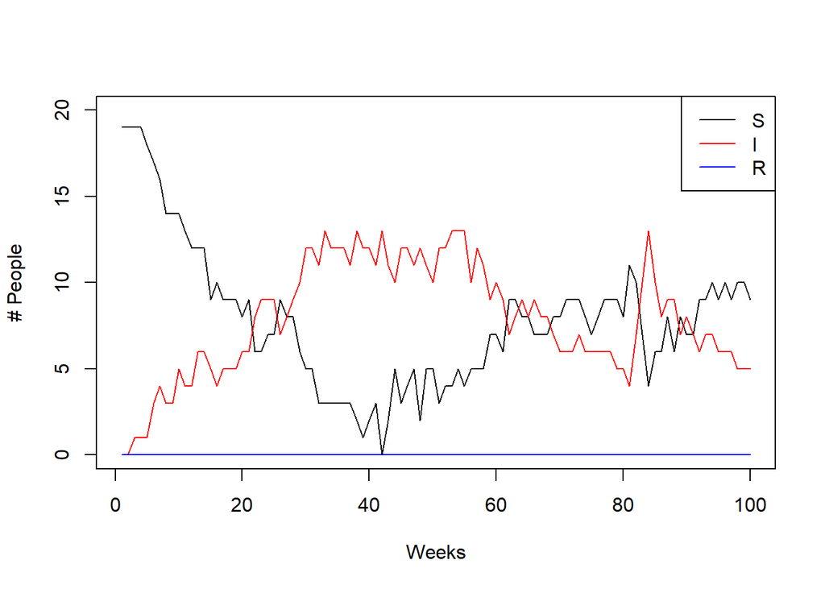

```r
initS <- 19
initI <- 1
beta <- 0.5
gamma<-1/5
tau<-1/10
alpha<-1
no.of.timesteps <- 100
pop <- c(rep(0,initS),rep(1,initI))
sim.table <- as.data.frame(matrix(NA, no.of.timesteps, 5))
colnames(sim.table) <- c('Day','S','E','I','R')

for(t in 1:no.of.timesteps)
{
  #Simulate what happens at each timestep
  sim.table$Day[t] <- t
  sim.table$S[t] <- sum(pop==0)
  sim.table$E[t] <- sum(pop==1)
  sim.table$I[t] <- sum(pop==2)
  sim.table$R[t] <- sum(pop==3)
  lambda <- beta*sum(pop==2)/length(pop)

  random.lambda <- runif(length(pop))
  random.gamma <- runif(length(pop))
  random.tau <- runif(length(pop))
  random.alpha <- runif(length(pop))

  for(i in 1:length(pop)){
    #Simulate what happens to each individual

    ## INFECTION ##
    if(pop[i]==0){
      if(random.lambda[i]<lambda){
        pop[i] <- 1
      }
    }

    ## LATENCY ##
    if(pop[i]==1){
      if(random.gamma[i]<gamma){
        pop[i] <- 2
      }
    }
    ## RECOVERY ##
    if(pop[i]==2){
      if(random.tau[i]<tau){
        pop[i] <- 3
      }
    }

    ## LOSS OF IMMUNITY ##
    if(pop[i]==3){
      if(random.alpha[i]<alpha){
        pop[i] <- 0
      }
    }

  }
}
sim.table

plot(sim.table$Day,sim.table$S,type='l',ylim=c(0,20),col='black',xlab="Weeks",ylab=("# People"))
lines(sim.table$Day,sim.table$I,col='red')
lines(sim.table$Day,sim.table$R,col='blue')
legend("topright", legend = c("S","I","R"), lwd = 1, col=c("black","red","blue"))
```

## A more general contact structure

Now, let’s explore a different conceptualization of the force of infection for an individual based model. In the example above, all individuals had an identical daily risk of infection given by lambda. In the real world, individuals self-organize into complex contact networks. The igraph R library (https://igraph.org/r/doc/plot.common.html) contains a lot of useful resources to generate and plot networks. Here is an example of how to generate a small world type network in R.

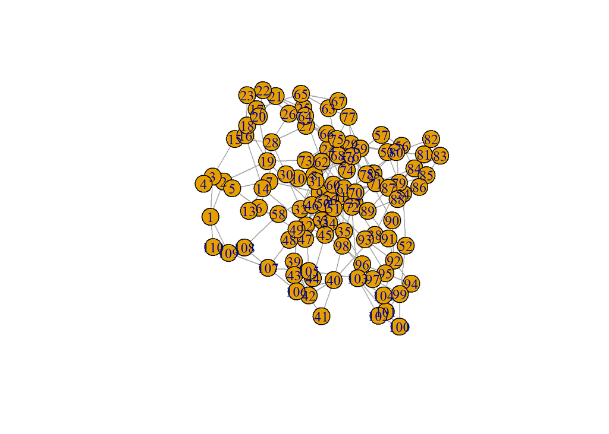

```r
library(igraph)
init_S <- 100
init_I <- 10
pop <- c(rep(0, init_S), rep(1, init_I))
connectivity <- 2
rewiring <- 0.15
nw <- sample_smallworld(1, length(pop), connectivity, rewiring)
plot(nw)
```

We can easily access the list of individual links:

```r
head(as_edgelist(nw, names = TRUE))
```

```
##      [,1] [,2]
## [1,]    1    2
## [2,]    2    3
## [3,]    3    4
## [4,]    4    5
## [5,]    5    6
## [6,]    6    7
```

Where each row establishes a link (edge) between the two individuals (vertices) on the graph. To find the neighbors (vertices it is linked to) of a specific individual on that network, we can simply write:

```r
neighborhood(nw, nodes = 1:3)
```

```
## [[1]]
## + 5/110 vertices, from 6d4e0d0:
## [1]   1   2   3 109 110
##
## [[2]]
## + 5/110 vertices, from 6d4e0d0:
## [1]  2  1  3  4 19
##
## [[3]]
## + 6/110 vertices, from 6d4e0d0:
## [1]  3  1  2  4  5 15
```

Let’s take the explicit meaning of beta – the number of mean infectious contacts per person per day. For each infectious person, we can then sample a random number of contacts to be had every day given a certain distribution. For a Poisson distribution that would look like:

```r
ncontacts <- rpois(1, beta)
```

So if you draw 10 numbers from that distribution with a beta of 1, you would get, e.g:

```r
rpois(10,1)
```

```
##  [1] 3 0 1 0 2 1 0 1 0 0
```

```r
pcontacted <- sample(as.vector(neighborhood(nw, nodes = i)[[1]][-1]), ncontacts, replace = TRUE)
```

### Exercise

8. Implement this type of transmission in the previous IBM model template. Note that we only care about contacts between infectious people and other people when it comes to the infection process. That means we should change the way the code in the `## INFECTION ##` section to reflect that.

```r
library("igraph")
init_S <- 100
init_I <- 10
beta <- 0.5
gamma <- 1 / 5
tau <- 1 / 10
alpha <- 1
no_of_timesteps <- 100
pop <- c(rep(0, init_S), rep(1, init_I))
sim_table <- as.data.frame(matrix(NA, no_of_timesteps, 5))
colnames(sim_table) <- c("Day", "S", "E", "I", "R")

connectivity <- 2
rewiring <- 0.15
nw <- sample_smallworld(1, length(pop), connectivity, rewiring)
plot(nw)

for(t in 1:no_of_timesteps){
    ## Simulate what happens at each timestep
    sim_table$Day[t] <- t
    sim_table$S[t] <- sum(pop == 0)
    sim_table$E[t] <- sum(pop == 1)
    sim_table$I[t] <- sum(pop == 2)
    sim_table$R[t] <- sum(pop == 3)

    random_gamma <- runif(length(pop))
    random_tau <- runif(length(pop))
    random_alpha <- runif(length(pop))

    for(i in seq_along(pop)){
        #Simulate what happens to each individual
        ## INFECTION ##
        if(pop[i] == 2) {
        # how many infectious contacts do you have today
        ncontacts <- rpois(1, beta)
            if (ncontacts > 0) {
                pcontacted <- sample(as.vector(neighborhood(nw, nodes = i)[[1]][-1]), ncontacts, replace = T)
                for (w in 1:ncontacts){
                    if (pop[pcontacted[w]] == 0) {
                        pop[pcontacted[w]] <-1
                    }
                }
            }
        }
        ## LATENCY ##
        if(pop[i] == 1){
            if(random_gamma[i] < gamma) { pop[i] <- 2}
        }
        ## RECOVERY ##
        if(pop[i] == 2){
            if(random_tau[i] < tau) { pop[i] <- 3 }
        }
        ## LOSS OF IMMUNITY ##
        if(pop[i] == 3){
            if(random_alpha[i] < alpha) { pop[i] <- 0 }
        }
        } # close loop for individuals

} # close loop for timesteps

# look at the results table
sim_table

# plot results
plot(sim_table$Day, sim_table$S, type = "l", ylim = c(0, length(pop)),
    col = "black", xlab = "Weeks", ylab = ("# People"))
lines(sim_table$Day, sim_table$I, col = "red")
lines(sim_table$Day, sim_table$R, col = "blue")
legend("topright", legend = c("S", "I", "R"), lwd = 1,
    col = c("black", "red", "blue"))
```

9. Compare the results from this network model with the IBM.R model. What are the key differences in terms of attack rate and rate of infection? Can you explain why those differences are to be expected?
10. Generate a plot with the mean equilibrium solutions (from at least 10 runs) for both models. How would you store the results of each run to calculate the mean solution?
11. How would you code an intervention that targets the most connected individuals (the top 10, e.g.), removing them from the network of contacts altogether? First consider how you would rank individuals according to their total number of possible contacts (neighbors).
12. How would the resulting dynamics look like in comparison? Propose a way to calculate the impact of that contact blocking intervention on incidence.

## A more realistic use case of informing networks from proxy data

Unless one can monitor all individual interactions for a large enough group of people, informing an individual based network in detail is nigh impossible. Several efforts have been made to characterize contact networks in different social contexts, resulting in macro-level abstractions that can be directly used as model inputs. The example above sets the network of (potentially infectious) contacts as a small world type network. In your experience as a researcher, you are likely to find gold standard contact matrices such as the ones used for respiratory infectious diseases, or mobility data in some form or another (from mobile phone usage records, travel surveys, etc). The data usually come in the form of a square matrix (except for individual level data like mobile phone records), which essentially stands as a proximity matrix between places/areas/groups. One of the most used contact matrices over recent years is the Prem K, Cook AR, Jit M (2017) Projecting social contact matrices in 152 countries using contact surveys and demographic data age contact dataset. Lets import the UK contact matrices to R.

```r
## import contact matrices
c_home <- as.matrix(read.table("contact_home.txt", sep = ",", header = F))
c_school <- as.matrix(read.table("contact_school.txt", sep = ",", header = F))
c_work <- as.matrix(read.table("contact_work.txt", sep = ",", header = F))
c_other <- as.matrix(read.table("contact_other.txt", sep = ",", header = F))
total_contacts <- c_home + c_school + c_other
```

You can use the plot.matrix library to quickly visualize the proximity between age groups.

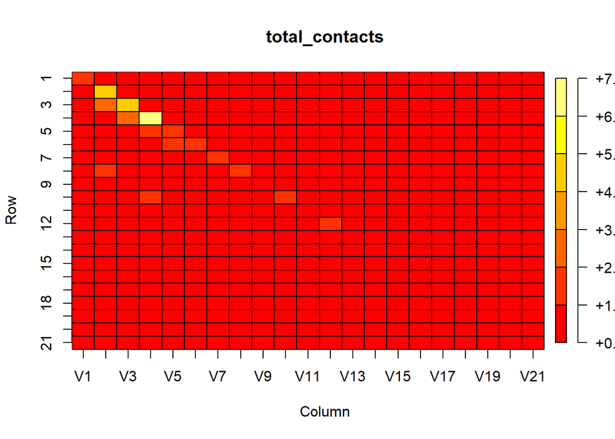

```r
library(plot.matrix)
plot(total_contacts)
```

Clearly, this is a strong diagonal matrix, representing high umber of contacts between people of the same age group, alongside some off-diagonal contacts which likely represent inter-generational contacts within families (children and their parents). Given the information in this matrix we could then inform a strongly age-dependent contact structure in our infection function. The first step is to assign each individual an age group. For that we use populations numbers (in thousands) from the UN 2019 Revision of World Population Prospects.

```r
## import age structure
popstruc <- read.csv("pop_structure_X.csv", header = T)
# convert from 1000s to total numbers
popstruc[, 2] <- popstruc[, 2] * 1000

## assign an age group to each individual
samplesize <- length(pop)
ages <- with(popstruc, sample(length(popstruc[, 1]),
    samplesize, p = (popstruc[, 2] / sum(popstruc[, 2])), replace = T))
```

We can then create our synthetic population contact network according to the adjacency matrix above.

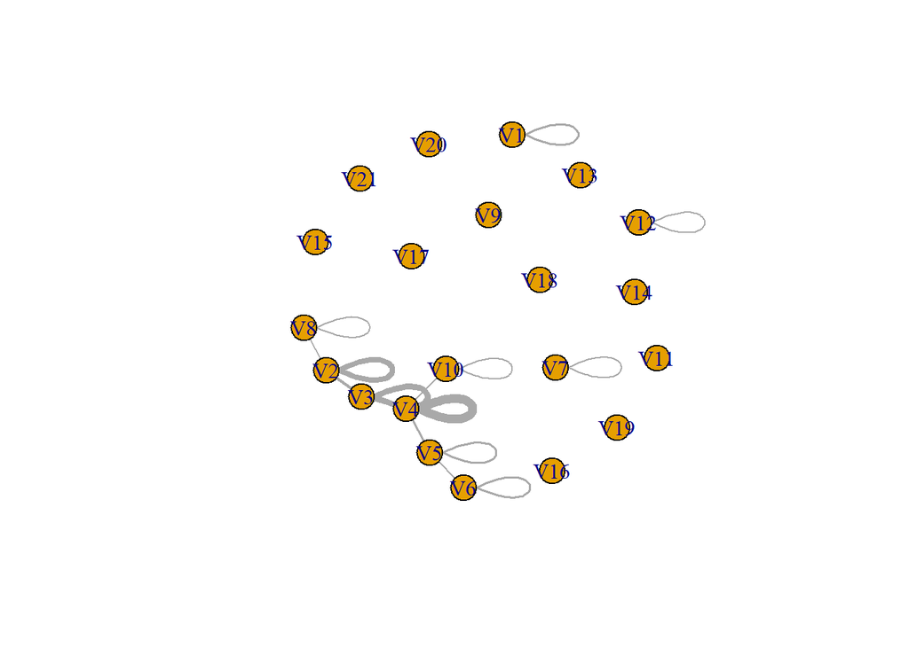

```r
## build network based on age
X <- as.matrix(total_contacts)
g <- graph_from_adjacency_matrix(X, mode = "lower",
    weighted = "weight", diag = T)
g2 <- delete.edges(g, which(E(g)$weight < 1))
plot(g2, edge.width = E(g2)$weight)
```

Note that I’ve deleted all contacts between groups with a weight lower than 1, meaning less than one contact, on average, between individuals in those groups per day. After initialising infections in individuals from random age groups, we can investigate how to write the code for our infection function.

```r
## init_Ialise infections in random individuals
starting_infs <- sample(length(pop), init_I)
pop[starting_infs] <- 1
```

Conceptually, what we need to accomplish is to write a block of code that for each infected person:

- draws a random number of potentially infectious contacts per day (ncontacts) according to our contact rate and probability that each contact is infectious.
- allocates those contacts to people of other age groups according to the distributions given by the total_contacts matrix.

```r
## INFECTION ##
        if (pop[i] == 2) {
            # how many infectious contacts do you have today
            ncontacts <- rpois(1, p * sum(total_contacts[ages[i], ]))
            # print(ncontacts)
            if (ncontacts > 0) {
                for (w in 1:ncontacts) {
                    # which age group do you get in contact with
                    target_age <- sample(length(total_contacts[, 1]), 1,
                    prob = total_contacts[ages[i], ], replace = TRUE)
                    target_person <- sample(which(ages == target_age), 1)
                    if (pop[target_person] == 0) {
                        pop[target_person] <- 1
                    }
                }
            }
        }
```

### Exercises

13. Run this code several times, exploring the importance of:
- the age groups where infection is seeded.
- the value of parameter p.
- making p age dependent (the viral/parasite load might be age dependent as well). Use p(age) = 1-exp(-k*age), e.g., where k is an additional parameter.
14. Conceptually explore how you could target specific age groups for intervention. What parameters or data objects would you change to reflect the desired changes such intervention would bring about?